# Workshop KI und Ethik

## Case Study 'Vorhersage Zulassung Workshop Teilnehmende'

### Zusammenfassung

Dieses Jupyter-Notebook ist eine umfassende Fallstudie zum Thema "KI und Ethik". Der Inhalt des Notebooks ist wie folgt:

1. **Einführung**: Das Notebook beginnt mit einer Einführung in die Fallstudie.
2. **Datengenerierung und -kennzeichnung**: Das Notebook importiert notwendige Bibliotheken und definiert Funktionen zur Generierung eines Datensatzes und zur Kennzeichnung desselben mit einem Entscheidungsbaum.
3. **Datenbeschreibung und -visualisierung**: Der generierte Datensatz der Workshop-Teilnehmer wird beschrieben und visualisiert.
4. **Modelltraining**: Der Datensatz wird in Trainings- und Testsets aufgeteilt und ein neuronales Netzwerkmodell wird trainiert.
5. **Modellevaluierung**: Die Leistung des Modells wird anhand von Metriken wie Genauigkeit, Präzision und Recall bewertet.
6. **Leistungsanalyse**: Die Leistung des Modells wird weiterhin mit einer Konfusionsmatrix und Visualisierungen analysiert.
7. **Korrelationsanalyse**: Das Notebook untersucht Korrelationen zwischen Geschlecht, Punktzahl und Zulassungsentscheidungen.
8. **Fairness-Metriken**: Fairness-Metriken wie statistische Paritätsdifferenz und disparater Einfluss werden berechnet und diskutiert.

Das Hauptziel dieses Notebooks besteht darin, das Potenzial für Bias in maschinellen Lernmodellen aufzuzeigen und die Bedeutung der Berücksichtigung von Fairness und Ethik in KI-Anwendungen zu betonen.

## 3. Datengenerierung und -kennzeichnung

Hier wird unserer biased Entscheidungsbaum gelernt. Die Testergebnisse (scores) sind natürlich wichtig, aber mit unserem verzerrten Denken, haben wir unsere Entscheidungen unterbewusst leider noch auf andere Attribute gelegt.

```python
def decisiontree(feature): #score hinzufügen korrigiert mit geschlecht, religion, income

  """
  MAPPING

  The position in the array indicates the number in the map
  gender = [male, female, non-binary, other]
  religion = [none, christian, muslim, jew, hindi, other]
  study_field = [natural sciences, formal sciences, arts & humanities, social sciences, other]
  BA/MA = [BA, MA]

  INPUT: array with features
  OUTPUT: label for each array entry

  """
  score = feature[7]
  if feature[0] > 2 and score < 80: #people of non-binary or other gender excluded for a score less than 80%
    return 0
  elif feature[0] > 1 and score < 50: #people of female gender excluded for a score less than 50%
    return 0
  elif feature[0] == 0 and score > 20: #people of male gender inluded for a score more than 20%
    return 1
  elif feature[1] < 15 or feature[1] >55 and score < 80: #old and young people excluded for a score less than 95%
    return 0
  elif feature[2] > 3 and score < 80: # people of other religiones than none, christian and mulsim excluded for a score less than 80%
    return 0
  elif feature[3] < 800 and score < 95 : #people with less income than 800€ per month excluded for a score less than 95%
    return 0
  elif feature[4] > 2: #people of other studyfields than natural and formal sciences excluded for a
    return 0
  elif feature[6] == 0 and feature[5] < 3 and score < 50: #BA students under 3rd semester excluded for score less than 50%
    return 0
  elif score < 25 : #people with a score less than 25% excluded
    return 0
  else:
    return 1
```

Hier werden zufällig Studierende generiert mit unterschiedlichen Merkmalen nach bestimmten Verteilungen (z.B. Normalverteilung oder Gleichverteilt).

Damit werden wir unsere tausende Trainings-Studierende generieren.

```python
def create_random_students(n, feats):
  """
  creates an example student with the paramters [[gender, age, religion, income, study field, semester, BA/MA], label]
  """
  s = np.zeros((len(feats),n))

  s[0] = np.random.choice(4, n, p=[0.4, 0.4, 0.15, 0.05]).astype(int) #add gender
  s[1] = np.round(np.absolute(np.random.normal(25,5,n))).astype(int) #add age
  s[2] = np.random.choice(6, n, p=[0.4, 0.3, 0.1, 0.1, 0.05, 0.05]).astype(int) #add religion
  s[3] = np.round(np.absolute(np.random.normal(1400,500,n))).astype(int) #add income
  s[4] = np.random.randint(6, size = n) # add study field
  s[5] = np.round(np.absolute(np.random.normal(6,2,n))).astype(int) #add semester
  s[6] = np.random.randint(2, size = n) #add BA/MA
  s[7] = np.random.randint(100, size = n) #add score
  s[8] = np.array([decisiontree(s_i) for s_i in s[0:8].T]).astype(int)

  df = pd.DataFrame(s.T.astype(int), columns=feats)

  return df
```

Diese Attribute haben die Studierenden

```python
feats = ['gender', 'age', 'religion', 'income', 'study field', 'semester', 'BA/MA', 'score', 'label']
```

## 4. Datenbeschreibung und -visualisierung

Die durch den 'Decision Tree' geschafenen Daten sind 'synthetische Daten', also Daten, die keine wirkliche Phänomene in der Welt darstellen. Sie sind Daten, die wir für euch geschaffen haben, damit ihr nachvollziehen könnt, wie Bias in ML auftreten kann. Die Zahlen sind jeweils den Strings (Text) zugeordnet, da die Algorithmen nur mit Zahlen rechnen können.

Zuerst erstellen wir zufällige Studierende, die nach bestimmten Verteilungen (wie z.B. Normalverteilung) generiert werden. Dabei wird nach dem Entscheidungsbaum jeder Studierenden ein zufälliges Label je nach Score und anderen Attributen vergeben.

```python
dic_gender = {'male' : 0, 'female': 1, 'nonbinary': 2, 'other': 3}
dic_religion = {'none': 0, 'christian': 1, 'muslim': 2, 'jew': 3, 'hindi': 4, 'other': 5}
dic_studyfield = {'natural sciences' : 0, 'formal sciences' : 1, 'arts & humanities' : 2, 'social sciences' : 3, 'other' : 4}
dic_BA = {'BA': 0, 'MA':1}
```

```python
n = 8*10**4
df = create_random_students(n, feats)
df.head(4)
```

|  | gender | age | religion | income | study field | semester | BA/MA | score | label |
| --- | --- | --- | --- | --- | --- | --- | --- | --- | --- |
| 0 | 1 | 25 | 0 | 1322 | 2 | 7 | 1 | 28 | 1 |
| 1 | 1 | 19 | 0 | 1299 | 2 | 8 | 1 | 3 | 0 |
| 2 | 0 | 14 | 0 | 1357 | 5 | 10 | 1 | 90 | 1 |
| 3 | 1 | 19 | 1 | 1058 | 3 | 9 | 1 | 58 | 0 |

```python
df.describe()[:5]
```

|  | gender | age | religion | income | study field | semester | BA/MA | score | label |
| --- | --- | --- | --- | --- | --- | --- | --- | --- | --- |
| count | 80000.000000 | 80000.000000 | 80000.000000 | 80000.000000 | 80000.000000 | 80000.000000 | 80000.000000 | 80000.000000 | 80000.000000 |
| mean | 0.853313 | 25.038238 | 1.252975 | 1399.963413 | 2.489925 | 6.007750 | 0.499688 | 49.453650 | 0.472013 |
| std | 0.853437 | 4.998871 | 1.443842 | 497.278829 | 1.710368 | 2.011775 | 0.500003 | 28.902642 | 0.499219 |
| min | 0.000000 | 2.000000 | 0.000000 | 0.000000 | 0.000000 | 0.000000 | 0.000000 | 0.000000 | 0.000000 |
| 25% | 0.000000 | 22.000000 | 0.000000 | 1060.000000 | 1.000000 | 5.000000 | 0.000000 | 24.000000 | 0.000000 |

## 5. Modelltraining

Um das neuronale Netz zu trainieren und die Genauigkeit der Vorhersagen zu überprüfen werden

1. Die oben erstellten Daten wurden in **Trainings- und Tesdaten** aufgeteilt.
2. Durch die Funktion '**MLP Classifier**' wird mit den Trainingsdaten das neuronale Netzwerk trainiert. Anschließend werden für die Testdaten durch das neuronale Netz Label voraussgesagt.
3. Es wird überprüft, wie viele der vorausgesagten Label mit den bekannten Labeln der Testdaten übereinstimmen, um die Genaugkeit des NN zu bestimmen.

```python
# 1. Aufteilen der Daten in Trainings- und Tesdaten

X_train, X_test, y_train, y_test = train_test_split_NN(df, feats)
```

```python
# 2. Trainieren der NN um ein Label vorherzusagen

def train_NN(X,y):
  """
  INPUT: dataframe with features and labels, list of features
  OUTPUT: trained model
  """
  model = MLPClassifier(hidden_layer_sizes=(50, ), max_iter=200, random_state=42)
  model.fit(X, y)
  return model
```

```python
def NN(X_train, X_test, y_train, y_test):
    model = train_NN(X_train, y_train)
    y_pred = model.predict(X_test)
    print(classification_report(y_test, y_pred))
    return model, X_train, X_test, y_train, y_test, y_pred
```

## 6. Modellevaluierung

Hier wird das Modell trainiert und die accuracy, recall und precision ausgegeben.

```python
# 3. Ausführen des NN
model = NN(X_train, X_test, y_train, y_test)
```

```
              precision    recall  f1-score   support

           0       0.97      0.94      0.95      8421
           1       0.93      0.97      0.95      7579

    accuracy                           0.95     16000
   macro avg       0.95      0.95      0.95     16000
weighted avg       0.95      0.95      0.95     16000
```

```python
#Needs to be defined in Workshop (here test_data used to see if it is running)
student_x = X_test
student_y = y_test
print(student_x.head(4))
```

```
       gender  age  religion  income  study field  semester  BA/MA  score
66076       2   16         0    1331            5         8      0     80
32015       1   17         0    1354            0         5      0      1
25392       2   31         3    1607            5         6      0     71
5282        0   19         0    1070            5         6      0     73
```

## Modellevaluierung

[figure not shown]

```python
graphs()
```

## Korrelationen zwischen Gender, score und Entscheidung für Zulassung

```python
corr = df[['gender', 'score', 'label']].corr()
corr.style.background_gradient(cmap='coolwarm')
```

|  | gender | score | label |
| --- | --- | --- | --- |
| gender | 1.000000 | -0.001739 | -0.478789 |
| score | -0.001739 | 1.000000 | 0.419464 |
| label | -0.478789 | 0.419464 | 1.000000 |

## Konfusionsmatrix

```python
#y_pred = train_NN(X_train, y_train).predict(X_test)
y_pred = model[5]
lmod = model[0]
```

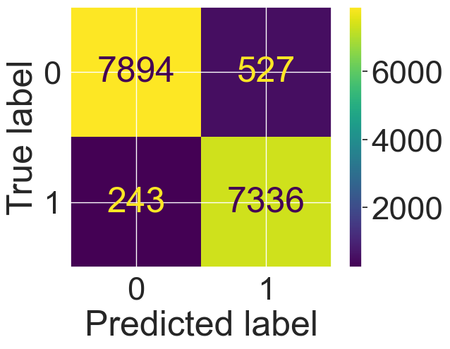

```python
# In Folien
#sns.set(font_scale=1)
cm = confusion_matrix(y_test, y_pred, labels=lmod.classes_)
disp = ConfusionMatrixDisplay(confusion_matrix=cm,
                              display_labels=lmod.classes_)

disp.plot()
plt.show()
```

### Fairness Metriken

Statistische Paritätsdifferenz <0 bedeutet, dass es einen größeren Vorteil für die priviligierte Gruppe in der Entscheidung gibt. Umso mehr die Metrik zu -1 tendiert, umso größer der Vorteil.

```python
fairness_metric()
```

```
Statistical Parity Difference between unprivileged and privileged groups for training set = -0.6961717296678764 and test set = -0.6969378285542122
Disparate Impact between unprivileged and privileged groups for training set = 0.11410470419088785 and test set = 0.12255724658166607
```

## Korrelationsentfernung

```python
def plot_heatmap(df, title):
    df['target'] = y
    df = df.rename(columns={"had_inpatient_days_True": "had_inpatient_days"})
    cols = list(df.columns)

    fig, ax = plt.subplots(figsize=(8, 6))
    ax.imshow(round(df.corr(), 2), cmap="coolwarm")

    # Show all ticks and label them with the respective list entries
    plt.setp(ax, xticks=np.arange(len(cols)), xticklabels=cols,
        yticks=np.arange(len(cols)), yticklabels=cols)

    # Rotate the tick labels and set their alignment.
    plt.setp(ax.get_xticklabels(), rotation=15, ha="right", rotation_mode="anchor")

    # Loop over data dimensions and create text annotations.
    for i in range(len(cols)):
        for j in range(len(cols)):
            ax.text(
                j,
                i,
                round(df.corr().to_numpy()[i, j], 2),
                ha="center",
                va="center",
            )

    ax.set_title(f"{title}")
    plt.show()
```